# TESTE_RECEITA

Juliana Santiago

6 de agosto de 2018

## TESTE RECEITA_RJ

```r
library(readxl)
library(tseries)
```

```r
library(ggplot2)
library(forecast)
library(foreign)
library(urca)
library(tidyquant)
library(TSstudio)
library(moments)
getwd()
```

```
## [1] "C:/Users/julia/Documents"
```

## Importando do Excel os dados mensais de receita bruta do Estado do Rio de Janeiro:

```r
RECEITA_RJ_R <- read_excel("~/UFF MESTRADO/4º SEMESTRE 2018.1/Regressão/RECEITA_RJ_R.xlsx")

View(RECEITA_RJ_R)
```

## Avisar ao R que se trata de uma série de tempo com frequência mensal e inÃ?cio em jan/2001:

```r
serie_receita<- ts(RECEITA_RJ_R, start = c(2001, 1), frequency = 12)
```

## Visualizando os dados ao longo do tempo:

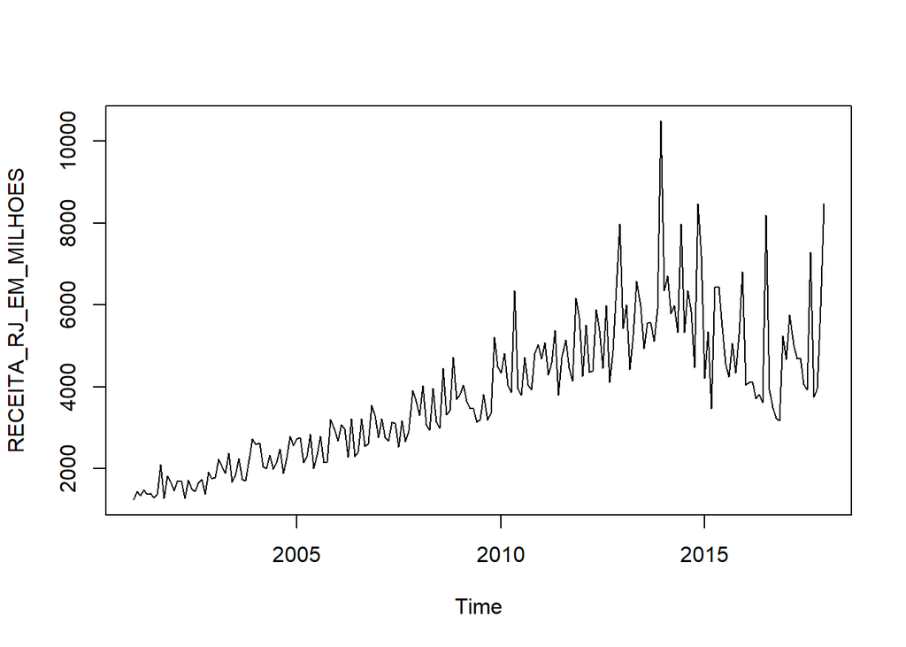

```r
plot(serie_receita)
```

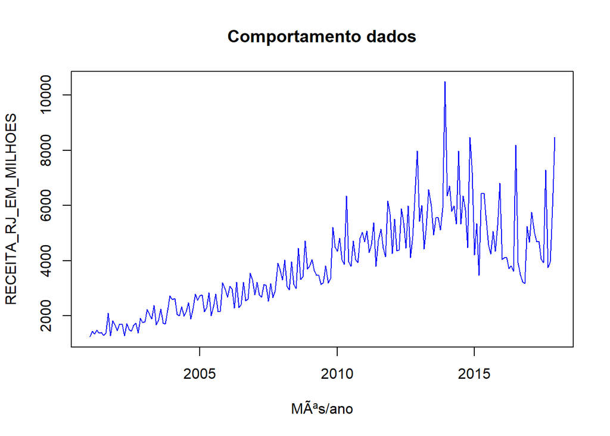

```r
plot(serie_receita, col='blue', main = 'Comportamento dados', xlab = 'MÃªs/ano')
```

## Observando a plotagem dos dados, a série parece ser não estacionária, pois não apresenta uma regularidade ao longo do tempo.

## EstatÃ?stica bÃ¡sica:

```r
summary(serie_receita)
```

```
##  RECEITA_RJ_EM_MILHOES
##  Min.   : 1239
##  1st Qu.: 2457
##  Median : 3678
##  Mean   : 3799
##  3rd Qu.: 4836
##  Max.   :10493
```

## HISTOGRAMA

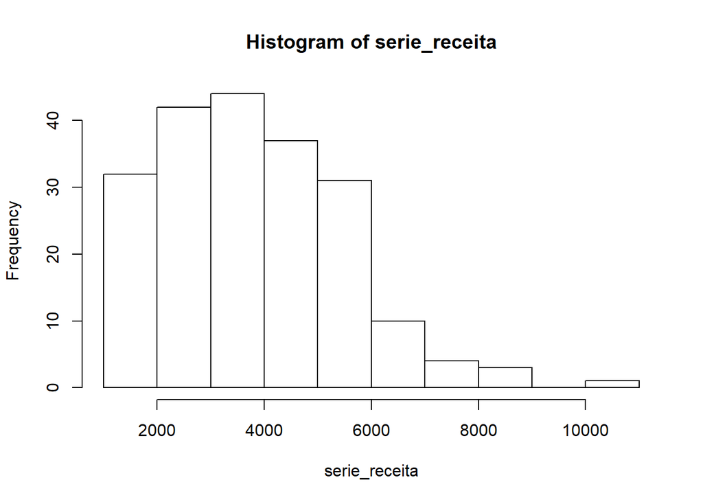

```r
hist(serie_receita)
```

## ASSIMETRIA

## Índice de assimetria (skewness). Se |Ia|<= 0,15, a distribuição dos dados é, aproximadamente, simétrica. Se 0,15<|Ia|<=1, a distribuição é moderadamente assimétrica. Se |Ia|>1, a distribuição é altamente assimétrica.

```r
skewness(serie_receita)
```

```
## RECEITA_RJ_EM_MILHOES
##             0.7381396
```

## |Ia|=0,7381 (0,15<|Ia|<=1), o que sugere que a distribuição de Receita_RJ é moderadamente assimétrica.

## CURTOSE

## Curtose (Ic) também é uma medida de assimetria. Se Ic = 0,263, a distribuição é mesocúrtica. Se Ic < 0,263, a distribuição é leptocúrtica. Se Ic>0,263, a distribuição é platicúrtica.

```r
kurtosis(serie_receita)
```

```
## RECEITA_RJ_EM_MILHOES
##              3.582738
```

## CORRELOGRAMA

## O correlograma é o gráfico utilizado em séries temporais para traçar as autocorrelações (também chamadas em inglês de ACF = autocorrelation function) em diversas defasagens. A análise desse gráfico permite entender se a série é aleatória ou possui alguma tendência ou sazonalidade.

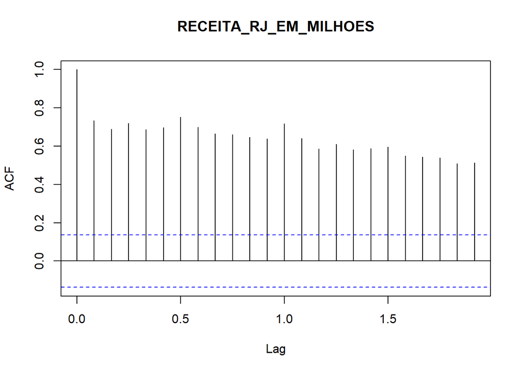

```r
acf(serie_receita)
```

## No gráfico, o eixo vertical indica a autocorrelação e o horizontal a defasagem. A linha tracejada azul indica onde é significativamente diferente de zero. Como é possÃ?vel ver na imagem,a maior parte dos valores ACF estão fora do limite da linha tracejada azul, Ou seja, autocorrelação diferente de zero, indicando que a série não é aleatória e que pode haver sazonalidade.

## De acordo com a função de autocovariância, a série é integrada, ou seja, não estacionária.

## ESTACIONARIDADE

## 1. Augmented Dickey-Fuller (ADF)

## H0 : tem raiz unitária (não é estacionária)

## H1 : não tem raiz unitária (é estacionária)

## Assim, se o p-valor for menor do que 5%, p<0,05, então rejeita-se a não-estacionariedade. Já se p>0,05, aceita-se a não-estacionariedade.

## Kwiatkowski, Phillips, Schmidt and Shin (1992) propuseram um teste para identificação da tendência e/ou nível estacionário.

## Temos então:

## H0 : estacionária

## HA : não estacionária

```r
adf.test(serie_receita)
```

```
##
##  Augmented Dickey-Fuller Test
##
## data:  serie_receita
## Dickey-Fuller = -2.3543, Lag order = 5, p-value = 0.4276
## alternative hypothesis: stationary
```

```r
kpss.test(serie_receita)
```

```
##
##  KPSS Test for Level Stationarity
##
## data:  serie_receita
## KPSS Level = 4.4723, Truncation lag parameter = 3, p-value = 0.01
```

## De acordo com o teste ADF, a série é não estacionária, pois o p-valor é alto (>0,05), logo, aceita-se a hipótese nula de que a série é não estacionária. E o teste KPSS corrobora isso, uma vez que o p-valor é baixo (<0,05), logo aceita-se a hipótese alternativa de não estacionaridade da série.

```r
library(fpp)
modelo <- auto.arima(serie_receita)
modelo
```

```
## Series: serie_receita
## ARIMA(0,1,1)(0,0,2)[12] with drift
##
## Coefficients:
##           ma1    sma1    sma2    drift
##       -0.8455  0.2683  0.2210  22.5468
## s.e.   0.0380  0.0796  0.0838  13.7891
##
## sigma^2 estimated as 737143:  log likelihood=-1658.83
## AIC=3327.66   AICc=3327.97   BIC=3344.23
```

## Aplicando-se a função autoarima, obtém-se um arima (0,1,1).

## Como a série é não estacionária, efetua-se a diferenciação da mesma.

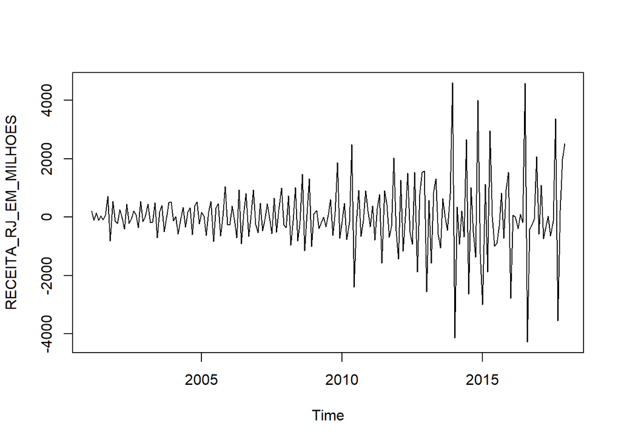

```r
dados_ts.diff <- diff(serie_receita)
plot.ts(dados_ts.diff)
```

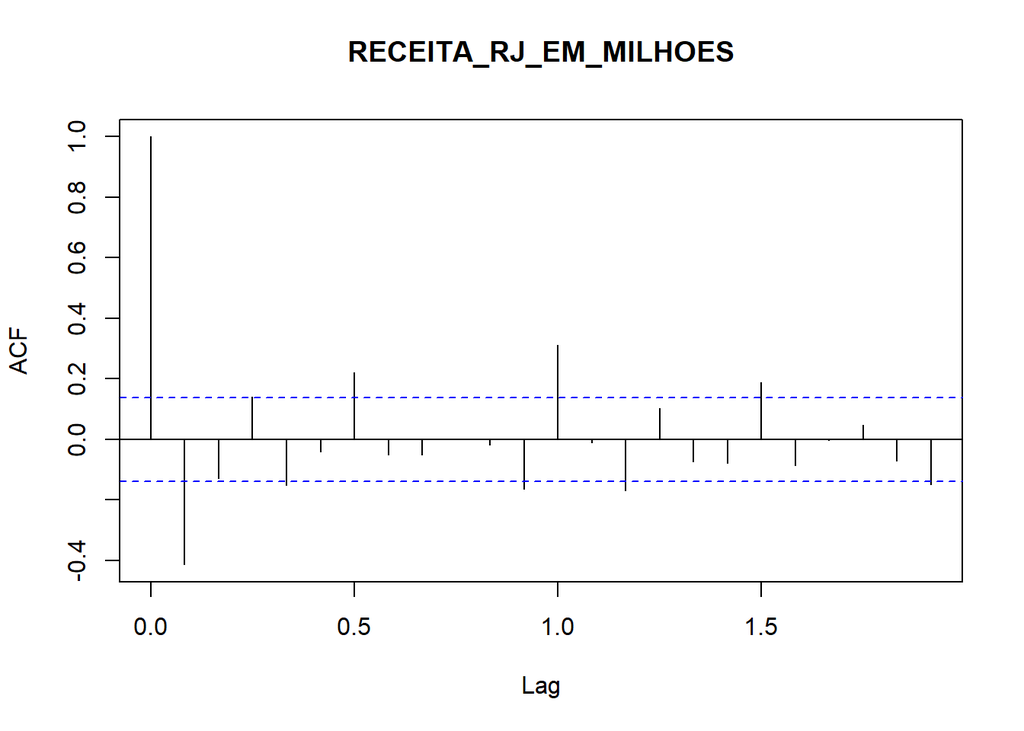

```r
acf(dados_ts.diff)
```

```r
adf.test(dados_ts.diff)
```

```
##
##  Augmented Dickey-Fuller Test
##
## data:  dados_ts.diff
## Dickey-Fuller = -10.593, Lag order = 5, p-value = 0.01
## alternative hypothesis: stationary
```

```r
kpss.test(dados_ts.diff)
```

```
##
##  KPSS Test for Level Stationarity
##
## data:  dados_ts.diff
## KPSS Level = 0.029726, Truncation lag parameter = 3, p-value = 0.1
```

## Observando a plotagem da série em primeira diferença, a mesma parece ser estacionária, pois aparenta um ruído.

## De acordo com o teste ADF, a série é estacionária, pois o p-valor é baixo (<0,05), logo, rejeita-se a hipótese nula de que a série é não estacionária. E o teste KPSS corrobora isso, uma vez que o p-valor é 0,1 (>0,05), logo aceita-se a hipótese nula de estacionaridade da série. Conforme indicado pelo resultado do autoarima.

## Testando um modelo adjacente

```r
adj <- arima(serie_receita, order=c(0,0,2))
adj
```

```
##
## Call:
## arima(x = serie_receita, order = c(0, 0, 2))
##
## Coefficients:
##          ma1     ma2  intercept
##       0.6126  0.2666  3806.9441
## s.e.  0.0760  0.0546   167.4304
##
## sigma^2 estimated as 1628989:  log likelihood = -1748.62,  aic = 3505.25
```

## Ao testar um modelo adjacente de arrima, percebe-se que este obteve um pior resultado. Portanto, usarei o modelo sugerido pelo autorima (0,1,1).

## RESÍDUOS

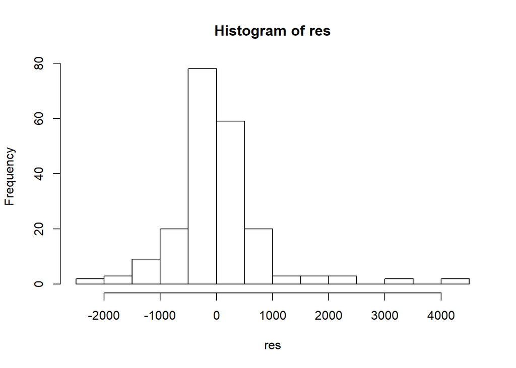

```r
res <- modelo$residuals
hist(res,20)
```

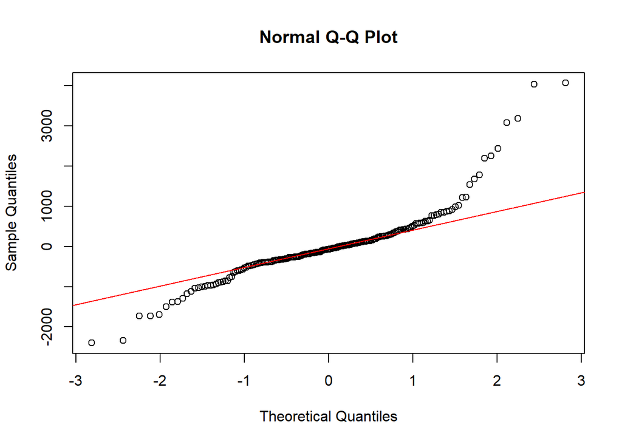

```r
qqnorm(res)
qqline(res, col="red")
```

## Observando o histograma dos resíduos, os mesmos parecem ter alguma discrepância nas caldas da distribuição, sugerindo a não normalidade da série. E olhando para o resultando do qqplot, percebe-se que os pontos seguem a linha, mas há maior discrepância nas caldas da distribuição, o que corrobora pra que a série não tenha distribuição normal.

```r
jarque.bera.test(res)
```

```
##
##  Jarque Bera Test
##
## data:  res
## X-squared = 405.86, df = 2, p-value < 2.2e-16
```

## O teste de Jarque-Bera tem como hipótese nula a normalidade. Assim, se o p-valor for menor do que 5%, p<0,05, então rejeita-se a normalidade. Já se p>0,05, aceita-se a normalidade.

```r
Box.test(res, type="Ljung")
```

```
##
##  Box-Ljung test
##
## data:  res
## X-squared = 0.078632, df = 1, p-value = 0.7792
```

## Como o p-valor do Box test é alto (>0,05), aceita-se a hipótese nula de que os valores de autocorrelação dos resíduos são nulos, ou seja, não são significantes.

## PREVISÃO

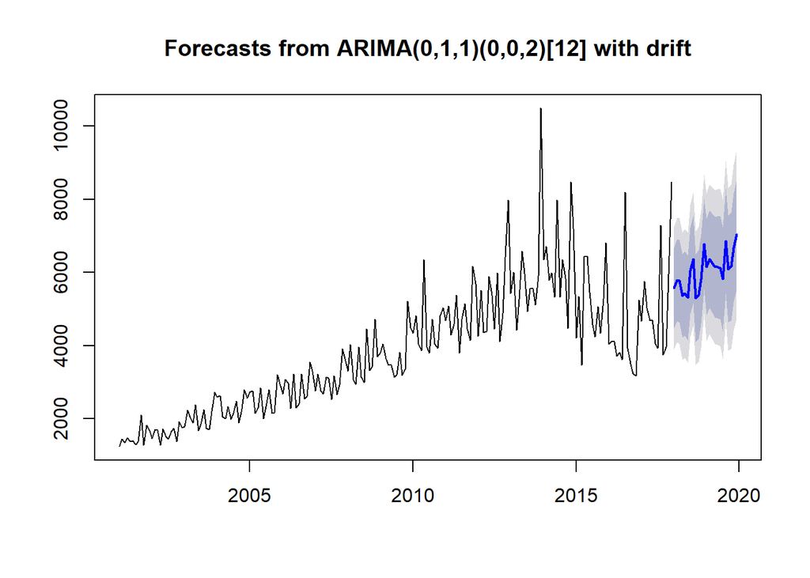

```r
modelo.forescast<-forecast(modelo, h=24)
plot(modelo.forescast)
```